# ClassificationOrg

```python
data_cleaned.isnull().sum()
```

```
Air Temp (°C)             0
Process Temp (°C)         0
Rotational Speed (RPM)    0
Torque (Nm)               0
Tool Wear (Seconds)       0
Failure Types             0
dtype: int64
```

ب-۲ اجرای فرآیندهای استانداردسازی (Standardization) و نرمال‌سازی (Normalization)

```python
from sklearn.model_selection import train_test_split
from sklearn.preprocessing import StandardScaler

X = data_cleaned.drop('Failure Types', axis=1)
y = data_cleaned['Failure Types']

X_train, X_test, y_train, y_test = train_test_split(X, y, test_size=0.2, random_state=42)

numeric_features = ['Air Temp (°C)', 'Process Temp (°C)', 'Rotational Speed (RPM)', 'Torque (Nm)', 'Tool Wear (Seconds)']

scaler = StandardScaler()
X_train[numeric_features] = scaler.fit_transform(X_train[numeric_features])
X_test[numeric_features] = scaler.transform(X_test[numeric_features])
```

```python
from sklearn.preprocessing import MinMaxScaler

numeric_features = ['Air Temp (°C)', 'Process Temp (°C)', 'Rotational Speed (RPM)', 'Torque (Nm)', 'Tool Wear (Seconds)']

minmax_scaler = MinMaxScaler()
X_train[numeric_features] = minmax_scaler.fit_transform(X_train[numeric_features])
X_test[numeric_features] = minmax_scaler.transform(X_test[numeric_features])
```

ج-۱ ایجاد ستون برچسب دوگانه (Failure / No Failure)

```python
data_cleaned['Failure_Binary'] = data_cleaned['Failure Types'].apply(
    lambda x: 'No Failure' if x == 'No Failure' else 'Failure'
)
```

ج-۲ توزیع برچسب‌ها (Bar Chart)

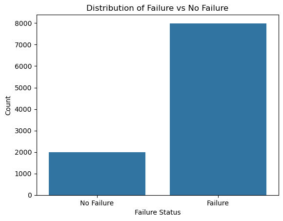

```python
import seaborn as sns
import matplotlib.pyplot as plt

# نمودار توزیع کلاس‌های Failure / No Failure
sns.countplot(x='Failure_Binary', data=data_cleaned)
plt.title('Distribution of Failure vs No Failure')
plt.xlabel('Failure Status')
plt.ylabel('Count')
plt.show()
```

```python
data_cleaned['Failure'] = data_cleaned['Failure Types'].apply(lambda x: 0 if x == 'No Failure' else 1)
```

ج-۴ متوازن‌سازی با SMOTE

```python
from sklearn.model_selection import train_test_split
from imblearn.over_sampling import SMOTE

X = data_cleaned[['Air Temp (°C)', 'Process Temp (°C)', 'Rotational Speed (RPM)',
                  'Torque (Nm)', 'Tool Wear (Seconds)']]

y = data_cleaned['Failure']

X_train, X_test, y_train, y_test = train_test_split(X, y,
                                                    test_size=0.2,
                                                    random_state=42,
                                                    stratify=y)

smote = SMOTE(random_state=42)
X_train_resampled, y_train_resampled = smote.fit_resample(X_train, y_train)

print("قبل SMOTE:", y_train.value_counts().to_dict())
print("بعد SMOTE:", dict(pd.Series(y_train_resampled).value_counts()))
```

```
قبل SMOTE: {1: 6394, 0: 1598}
بعد SMOTE: {1: 6394, 0: 6394}
```

ج-۵ آموزش ۳ مدل مختلف روی داده‌های آموزش، سپس ارزیابی روی داده‌های آزمون

```python
from sklearn.linear_model import LogisticRegression
from sklearn.neighbors import KNeighborsClassifier
from sklearn.svm import LinearSVC
from sklearn.svm import SVC
from sklearn.metrics import classification_report, confusion_matrix, ConfusionMatrixDisplay
import matplotlib.pyplot as plt
```

```python
# تابعی برای آموزش، پیش‌بینی و گزارش عملکرد مدل
def evaluate_model(model, model_name):
    # آموزش روی داده‌های متعادل‌شده‌ی آموزش
    model.fit(X_train_resampled, y_train_resampled)

    # پیش‌بینی روی داده‌های آزمون (غیر متعادل)
    y_pred = model.predict(X_test)

    # نمایش نام مدل
    print(f"\n🔹 {model_name}")

    # ماتریس سردرگمی
    cm = confusion_matrix(y_test, y_pred)
    disp = ConfusionMatrixDisplay(confusion_matrix=cm, display_labels=model.classes_)
    disp.plot(cmap='Blues')
    plt.title(f"Confusion Matrix - {model_name}")
    plt.grid(False)
    plt.show()

    # گزارش دسته‌بندی
    print("Classification Report:")
    print(classification_report(y_test, y_pred))
```

```
🔹 Logistic Regression
```

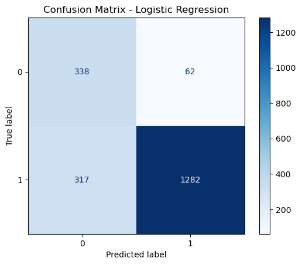

```
Classification Report:
              precision    recall  f1-score   support

           0       0.52      0.84      0.64       400
           1       0.95      0.80      0.87      1599

    accuracy                           0.81      1999
   macro avg       0.73      0.82      0.76      1999
weighted avg       0.87      0.81      0.83      1999


🔹 K-Nearest Neighbors
```

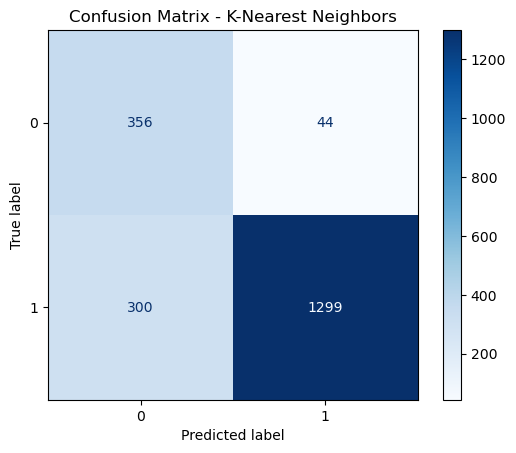

```
Classification Report:
              precision    recall  f1-score   support

           0       0.54      0.89      0.67       400
           1       0.97      0.81      0.88      1599

    accuracy                           0.83      1999
   macro avg       0.75      0.85      0.78      1999
weighted avg       0.88      0.83      0.84      1999


🔹 LinearSVC (Faster SVM)
```

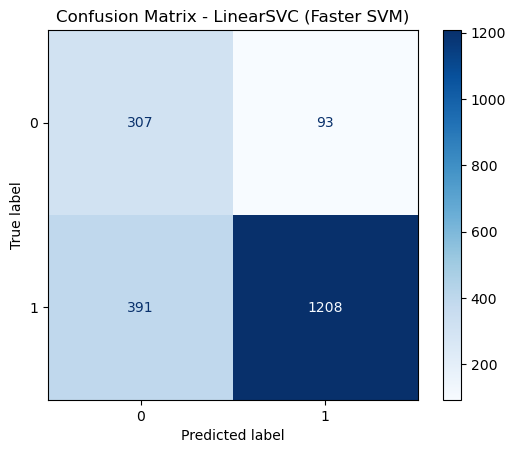

```
Classification Report:
              precision    recall  f1-score   support

           0       0.44      0.77      0.56       400
           1       0.93      0.76      0.83      1599

    accuracy                           0.76      1999
   macro avg       0.68      0.76      0.70      1999
weighted avg       0.83      0.76      0.78      1999
```

```python
# 1. Logistic Regression
log_reg = LogisticRegression(max_iter=1000, random_state=42)
evaluate_model(log_reg, "Logistic Regression")

# 2. K-Nearest Neighbors (K=5)
knn = KNeighborsClassifier(n_neighbors=5)
evaluate_model(knn, "K-Nearest Neighbors")

# SVM بهینه‌شده برای سرعت
svm_fast = LinearSVC(max_iter=10000, random_state=42)
evaluate_model(svm_fast, "LinearSVC (Faster SVM)")
```

```python
# مدل SVM با کرنل RBF
svm_rbf = SVC(kernel='rbf', random_state=42)
svm_rbf.fit(X_train_resampled, y_train_resampled)

y_pred_rbf = svm_rbf.predict(X_test)

print("SVM با هسته RBF:")
print(classification_report(y_test, y_pred_rbf))
print("Confusion Matrix:")
print(confusion_matrix(y_test, y_pred_rbf))
```

```
SVM با هسته RBF:
              precision    recall  f1-score   support

           0       0.41      1.00      0.58       400
           1       1.00      0.64      0.78      1599

    accuracy                           0.71      1999
   macro avg       0.71      0.82      0.68      1999
weighted avg       0.88      0.71      0.74      1999

Confusion Matrix:
[[ 400    0]
 [ 575 1024]]
```

ج-٦ مقایسه عملکرد مدل‌ها با استفاده از معیارهای ارزیابی و بصری‌سازی

```python
from sklearn.linear_model import LogisticRegression
from sklearn.neighbors import KNeighborsClassifier
from sklearn.svm import LinearSVC, SVC
from sklearn.preprocessing import StandardScaler
from sklearn.pipeline import make_pipeline

# مدل‌ها
model_lr = LogisticRegression(max_iter=1000, random_state=42)
model_knn = KNeighborsClassifier()
model_svc_linear = LinearSVC(max_iter=1000, random_state=42)
model_svc_rbf = make_pipeline(StandardScaler(), SVC(kernel='rbf', random_state=42))  # با نرمال‌سازی

# آموزش
model_lr.fit(X_train_resampled, y_train_resampled)
model_knn.fit(X_train_resampled, y_train_resampled)
model_svc_linear.fit(X_train_resampled, y_train_resampled)
model_svc_rbf.fit(X_train_resampled, y_train_resampled)
```

```
Pipeline(steps=[('standardscaler', StandardScaler()),
                ('svc', SVC(random_state=42))])
```

```python
# پیش‌بینی
y_pred_lr = model_lr.predict(X_test)
y_pred_knn = model_knn.predict(X_test)
y_pred_svc_linear = model_svc_linear.predict(X_test)
y_pred_svc_rbf = model_svc_rbf.predict(X_test)
```

```
🔹 Logistic Regression

Accuracy: 0.8104052026013007
Classification Report:
               precision    recall  f1-score   support

           0       0.52      0.84      0.64       400
           1       0.95      0.80      0.87      1599

    accuracy                           0.81      1999
   macro avg       0.73      0.82      0.76      1999
weighted avg       0.87      0.81      0.83      1999
```

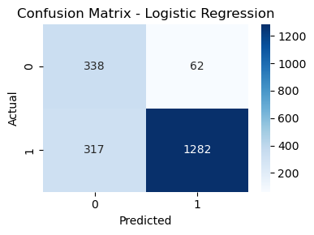

```
🔹 K-Nearest Neighbors

Accuracy: 0.8279139569784892
Classification Report:
               precision    recall  f1-score   support

           0       0.54      0.89      0.67       400
           1       0.97      0.81      0.88      1599

    accuracy                           0.83      1999
   macro avg       0.75      0.85      0.78      1999
weighted avg       0.88      0.83      0.84      1999
```

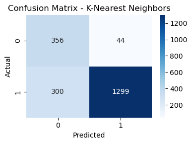

```
🔹 Linear SVC

Accuracy: 0.7578789394697348
Classification Report:
               precision    recall  f1-score   support

           0       0.44      0.77      0.56       400
           1       0.93      0.76      0.83      1599

    accuracy                           0.76      1999
   macro avg       0.68      0.76      0.70      1999
weighted avg       0.83      0.76      0.78      1999
```

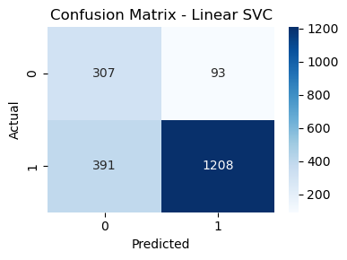

```
🔹 RBF SVC

Accuracy: 1.0
Classification Report:
               precision    recall  f1-score   support

           0       1.00      1.00      1.00       400
           1       1.00      1.00      1.00      1599

    accuracy                           1.00      1999
   macro avg       1.00      1.00      1.00      1999
weighted avg       1.00      1.00      1.00      1999
```

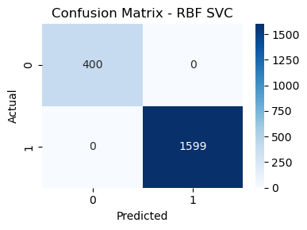

```python
from sklearn.metrics import accuracy_score, classification_report, confusion_matrix

models = {
    "Logistic Regression": y_pred_lr,
    "K-Nearest Neighbors": y_pred_knn,
    "Linear SVC": y_pred_svc_linear,
    "RBF SVC": y_pred_svc_rbf
}

for name, y_pred in models.items():
    print(f"\n🔹 {name}\n")
    print("Accuracy:", accuracy_score(y_test, y_pred))
    print("Classification Report:\n", classification_report(y_test, y_pred))
    cm = confusion_matrix(y_test, y_pred)

    # رسم ماتریس آشفتگی
    plt.figure(figsize=(4, 3))
    sns.heatmap(cm, annot=True, fmt='d', cmap='Blues')
    plt.title(f"Confusion Matrix - {name}")
    plt.xlabel("Predicted")
    plt.ylabel("Actual")
    plt.tight_layout()
    plt.show()
```

```python
import pandas as pd

accuracy_table = {
    "Model": [],
    "Accuracy": []
}

for name, y_pred in models.items():
    acc = accuracy_score(y_test, y_pred)
    accuracy_table["Model"].append(name)
    accuracy_table["Accuracy"].append(acc)

df_accuracy = pd.DataFrame(accuracy_table)
print(df_accuracy)
```

```
                 Model  Accuracy
0  Logistic Regression  0.810405
1  K-Nearest Neighbors  0.827914
2           Linear SVC  0.757879
3              RBF SVC  1.000000
```

ج-7 تنظیم هایپرپارامترها با GridSearchCV

```python
from sklearn.linear_model import LogisticRegression
from sklearn.model_selection import GridSearchCV

param_grid_lr = {
    'C': [0.01, 0.1, 1, 10],
    'penalty': ['l2'],
    'solver': ['liblinear', 'lbfgs']
}

grid_lr = GridSearchCV(LogisticRegression(max_iter=1000), param_grid_lr, cv=5, scoring='accuracy')
grid_lr.fit(X_train_resampled, y_train_resampled)

print("🔹 Best parameters (Logistic Regression):", grid_lr.best_params_)
print("🔹 Best accuracy (train, cross-val):", grid_lr.best_score_)

best_lr = grid_lr.best_estimator_
```

```
🔹 Best parameters (Logistic Regression): {'C': 0.1, 'penalty': 'l2', 'solver': 'lbfgs'}
🔹 Best accuracy (train, cross-val): 0.8341417250412257
```

```python
from sklearn.neighbors import KNeighborsClassifier

param_grid_knn = {
    'n_neighbors': list(range(3, 16)),
    'weights': ['uniform', 'distance']
}

grid_knn = GridSearchCV(KNeighborsClassifier(), param_grid_knn, cv=5, scoring='accuracy')
grid_knn.fit(X_train_resampled, y_train_resampled)

print("🔹 Best parameters (KNN):", grid_knn.best_params_)
print("🔹 Best accuracy (train, cross-val):", grid_knn.best_score_)

best_knn = grid_knn.best_estimator_
```

```
🔹 Best parameters (KNN): {'n_neighbors': 3, 'weights': 'distance'}
🔹 Best accuracy (train, cross-val): 0.9147637156643997
```

```python
from sklearn.svm import LinearSVC

param_grid_lsvc = {
    'C': [0.01, 0.1, 1, 10],
    'max_iter': [1000, 5000]
}

grid_lsvc = GridSearchCV(LinearSVC(), param_grid_lsvc, cv=5, scoring='accuracy')
grid_lsvc.fit(X_train_resampled, y_train_resampled)

print("🔹 Best parameters (LinearSVC):", grid_lsvc.best_params_)
print("🔹 Best accuracy (train, cross-val):", grid_lsvc.best_score_)

best_lsvc = grid_lsvc.best_estimator_
```

```
🔹 Best parameters (LinearSVC): {'C': 10, 'max_iter': 1000}
🔹 Best accuracy (train, cross-val): 0.788472980241273
```

```python
from sklearn.svm import SVC

param_grid_rbf = {
    'C': [0.1, 1, 10],
    'gamma': ['scale', 0.01, 0.1, 1]
}

grid_rbf = GridSearchCV(SVC(kernel='rbf'), param_grid_rbf, cv=5, scoring='accuracy')
grid_rbf.fit(X_train_resampled, y_train_resampled)

print("🔹 Best parameters (RBF SVC):", grid_rbf.best_params_)
print("🔹 Best accuracy (train, cross-val):", grid_rbf.best_score_)

best_rbf = grid_rbf.best_estimator_
```

```
🔹 Best parameters (RBF SVC): {'C': 10, 'gamma': 'scale'}
🔹 Best accuracy (train, cross-val): 0.8681572576835332
```

```python
from sklearn.metrics import accuracy_score

models = {
    "Logistic Regression": best_lr,
    "KNN": best_knn,
    "Linear SVC": best_lsvc,
    "RBF SVC": best_rbf
}

for name, model in models.items():
    y_pred = model.predict(X_test)
    acc = accuracy_score(y_test, y_pred)
    print(f"{name} Test Accuracy: {acc:.4f}")
```

```
Logistic Regression Test Accuracy: 0.8104
KNN Test Accuracy: 0.8599
Linear SVC Test Accuracy: 0.7579
RBF SVC Test Accuracy: 0.8009
```

ج-8 بررسی و مقایسه عملکرد مدل‌ها با معیارهای ارزیابی

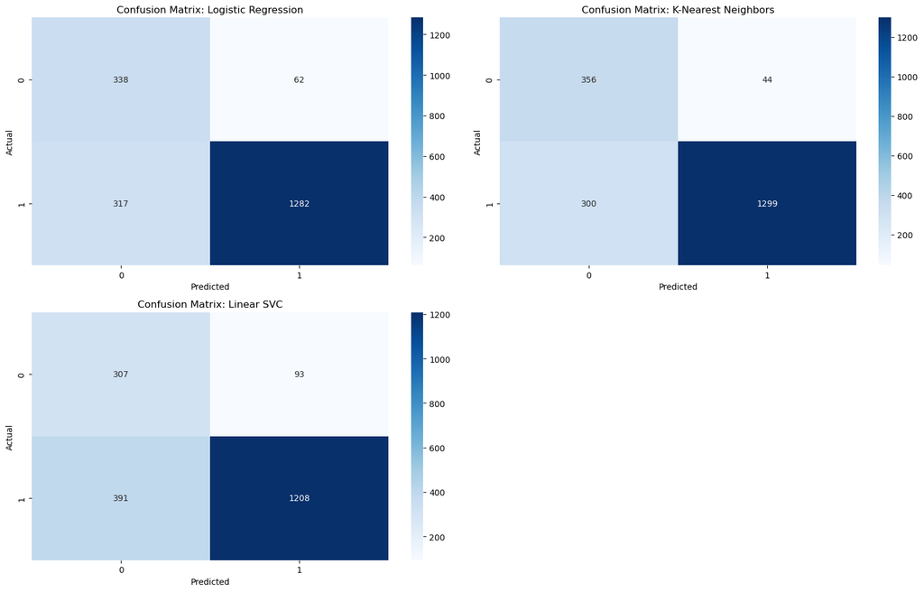

```
 جدول مقایسه عملکرد مدل‌ها:

                 Model  Accuracy  Precision (avg)  Recall (avg)  \
0  Logistic Regression  0.810405         0.866258      0.810405
1  K-Nearest Neighbors  0.827914         0.882284      0.827914
2           Linear SVC  0.757879         0.830730      0.757879

   F1-score (avg)
0        0.825104
1        0.841286
2        0.778295
```

```python
from sklearn.metrics import accuracy_score, classification_report, confusion_matrix
import seaborn as sns
import matplotlib.pyplot as plt
import pandas as pd

# فرض: این مدل‌ها از قبل آموزش‌دیده هستند
# اگر این‌ها قبلاً تعریف نشدن، ابتدا باید مدل‌ها آموزش ببینند:
# model_lr, model_knn, model_svc, model_rbf_svc

models = {
    "Logistic Regression": model_lr,
    "K-Nearest Neighbors": model_knn,
    "Linear SVC": svm_fast
}

results = []

plt.figure(figsize=(16, 10))
for idx, (name, model) in enumerate(models.items(), 1):
    y_pred = model.predict(X_test)
    acc = accuracy_score(y_test, y_pred)
    report = classification_report(y_test, y_pred, output_dict=True)
    results.append({
        "Model": name,
        "Accuracy": acc,
        "Precision (avg)": report['weighted avg']['precision'],
        "Recall (avg)": report['weighted avg']['recall'],
        "F1-score (avg)": report['weighted avg']['f1-score']
    })

    # نمایش ماتریس آشفتگی
    plt.subplot(2, 2, idx)
    cm = confusion_matrix(y_test, y_pred)
    sns.heatmap(cm, annot=True, fmt='d', cmap='Blues')
    plt.title(f"Confusion Matrix: {name}")
    plt.xlabel('Predicted')
    plt.ylabel('Actual')

plt.tight_layout()
plt.show()

# نمایش جدول مقایسه‌ای
comparison_df = pd.DataFrame(results)
print("\n جدول مقایسه عملکرد مدل‌ها:\n")
print(comparison_df)
```

د-1 تقسیم داده‌های پالایش‌شده و آموزش مدل ها

```python
# لیست ویژگی‌ها (features) و برچسب هدف (target)
features = ['Air Temp (°C)', 'Process Temp (°C)', 'Rotational Speed (RPM)',
            'Torque (Nm)', 'Tool Wear (Seconds)']
target = 'Failure Types'
```

```python
target = 'Failure Types Encoded'  # چون این ستون مقدار گمشده ندارد
```

```python
X = dataset[features]
y = dataset[target]

from sklearn.model_selection import train_test_split

X_train_d, X_test_d, y_train_d, y_test_d = train_test_split(
    X, y, test_size=0.2, random_state=42, stratify=y
)
```

```python
dataset_clean = dataset.dropna(subset=['Failure Types'])

X = dataset_clean[features]
y = dataset_clean['Failure Types']

X_train_d, X_test_d, y_train_d, y_test_d = train_test_split(
    X, y, test_size=0.2, random_state=42, stratify=y
)
```

```python
from sklearn.model_selection import train_test_split

X = dataset[features]
y = dataset[target]

X_train_d, X_test_d, y_train_d, y_test_d = train_test_split(
    X, y, test_size=0.2, random_state=42, stratify=y
)
```

```python
from sklearn.preprocessing import StandardScaler

scaler = StandardScaler()
X_train_d_scaled = scaler.fit_transform(X_train_d)
X_test_d_scaled = scaler.transform(X_test_d)
```

```python
from sklearn.impute import SimpleImputer
from sklearn.preprocessing import StandardScaler

# ابتدا ایمپیوتر رو روی داده آموزش fit و transform می‌کنیم
imputer = SimpleImputer(strategy='mean')
X_train_d_imputed = imputer.fit_transform(X_train_d)
X_test_d_imputed = imputer.transform(X_test_d)

# حالا استانداردسازی
scaler = StandardScaler()
X_train_d_scaled = scaler.fit_transform(X_train_d_imputed)
X_test_d_scaled = scaler.transform(X_test_d_imputed)
```

```python
from sklearn.neighbors import KNeighborsClassifier

model_knn_d = KNeighborsClassifier()
model_knn_d.fit(X_train_d_scaled, y_train_d)
```

```
KNeighborsClassifier()
```

```python
from sklearn.tree import DecisionTreeClassifier

model_dt_d = DecisionTreeClassifier(random_state=42)
model_dt_d.fit(X_train_d_scaled, y_train_d)
```

```
DecisionTreeClassifier(random_state=42)
```

```python
from sklearn.ensemble import RandomForestClassifier

model_rf_d = RandomForestClassifier(random_state=42)
model_rf_d.fit(X_train_d_scaled, y_train_d)
```

```
RandomForestClassifier(random_state=42)
```

```python
from sklearn.linear_model import LogisticRegression

model_lr_d = LogisticRegression(max_iter=1000, random_state=42)
model_lr_d.fit(X_train_d_scaled, y_train_d)
```

```
LogisticRegression(max_iter=1000, random_state=42)
```

```python
import warnings
from sklearn.exceptions import UndefinedMetricWarning

warnings.filterwarnings("ignore", category=UndefinedMetricWarning)
```

```python
from sklearn.metrics import confusion_matrix, accuracy_score, classification_report
import pandas as pd

models = {
    'KNN': model_knn_d,
    'Decision Tree': model_dt_d,
    'Random Forest': model_rf_d,
    'Logistic Regression': model_lr_d,
}

results = []

for name, model in models.items():
    y_pred = model.predict(X_test_d_scaled)  # پیش‌بینی برچسب‌ها با داده‌های تست استاندارد شده
    cm = confusion_matrix(y_test_d, y_pred)
    acc = accuracy_score(y_test_d, y_pred)
    report = classification_report(y_test_d, y_pred, output_dict=True)

    results.append({
        'Model': name,
        'Accuracy': acc,
        'Confusion Matrix': cm,
        'Classification Report': report
    })

# ساخت جدول خلاصه دقت‌ها
df_summary = pd.DataFrame({
    'Model': [r['Model'] for r in results],
    'Accuracy': [r['Accuracy'] for r in results]
})

print(df_summary)

# چاپ ماتریس آشفتگی و گزارش طبقه‌بندی برای هر مدل
for r in results:
    print(f"\nModel: {r['Model']}")
    print("Confusion Matrix:")
    print(r['Confusion Matrix'])
    print("Classification Report:")
    print(pd.DataFrame(r['Classification Report']).transpose())
    print("\n" + "-"*40 + "\n")
```

```
                 Model  Accuracy
0                  KNN    0.9990
1        Decision Tree    0.9975
2        Random Forest    0.9990
3  Logistic Regression    0.9985

Model: KNN
Confusion Matrix:
[[400   0   0   0   0   0]
 [  0 399   0   0   0   0]
 [  0   0 399   0   0   0]
 [  0   0   0 400   0   0]
 [  0   0   0   0 400   0]
 [  0   0   2   0   0   0]]
Classification Report:
              precision    recall  f1-score   support
0              1.000000  1.000000  1.000000   400.000
1              1.000000  1.000000  1.000000   399.000
2              0.995012  1.000000  0.997500   399.000
3              1.000000  1.000000  1.000000   400.000
4              1.000000  1.000000  1.000000   400.000
5              0.000000  0.000000  0.000000     2.000
accuracy       0.999000  0.999000  0.999000     0.999
macro avg      0.832502  0.833333  0.832917  2000.000
weighted avg   0.998005  0.999000  0.998501  2000.000

----------------------------------------


Model: Decision Tree
Confusion Matrix:
[[399   0   0   0   0   1]
 [  0 397   0   0   0   2]
 [  0   0 399   0   0   0]
 [  0   0   0 400   0   0]
 [  0   0   0   0 400   0]
 [  0   0   2   0   0   0]]
Classification Report:
              precision    recall  f1-score    support
0              1.000000  0.997500  0.998748   400.0000
```

[output cut: 41 more lines]

```
 [  0   0   0   0 400   0]
 [  0   0   2   0   0   0]]
Classification Report:
              precision    recall  f1-score    support
0              1.000000  1.000000  1.000000   400.0000
1              1.000000  0.997494  0.998745   399.0000
2              0.992537  1.000000  0.996255   399.0000
3              1.000000  1.000000  1.000000   400.0000
4              1.000000  1.000000  1.000000   400.0000
5              0.000000  0.000000  0.000000     2.0000
accuracy       0.998500  0.998500  0.998500     0.9985
macro avg      0.832090  0.832916  0.832500  2000.0000
weighted avg   0.997511  0.998500  0.998002  2000.0000

----------------------------------------
```

د-3 بهینه‌سازی هایپرپارامترهای مدل‌ها با GridSearchCV

```python
from sklearn.model_selection import GridSearchCV

# تعریف مدل‌ها
model_logistic = LogisticRegression(max_iter=1000)
model_knn = KNeighborsClassifier()
model_rf = RandomForestClassifier(random_state=42)

# تعریف پارامترهایی که می‌خواهیم جستجو کنیم
param_grid_logistic = {
    'C': [0.01, 0.1, 1, 10],          # ضریب تنظیم (Regularization)
    'solver': ['liblinear', 'lbfgs']  # الگوریتم بهینه‌سازی
}

param_grid_knn = {
    'n_neighbors': list(range(1, 21))  # تغییر مقدار k از 1 تا 20
}

param_grid_rf = {
    'n_estimators': [50, 100, 200],  # تعداد درخت‌ها
    'max_depth': [None, 10, 20, 30]  # عمق درخت‌ها
}

# ایجاد GridSearchCV برای هر مدل
grid_logistic = GridSearchCV(model_logistic, param_grid_logistic, cv=5, scoring='accuracy', n_jobs=-1)
grid_knn = GridSearchCV(model_knn, param_grid_knn, cv=5, scoring='accuracy', n_jobs=-1)
grid_rf = GridSearchCV(model_rf, param_grid_rf, cv=5, scoring='accuracy', n_jobs=-1)

# اجرای جستجو روی داده‌های آموزش (استفاده از داده‌های مقیاس شده اگر داری)
grid_logistic.fit(X_train_d_scaled, y_train_d)
grid_knn.fit(X_train_d_scaled, y_train_d)
grid_rf.fit(X_train_d_scaled, y_train_d)

# نمایش بهترین پارامترها و بهترین دقت
print("Logistic Regression best params:", grid_logistic.best_params_)
print("Logistic Regression best accuracy:", grid_logistic.best_score_)

print("KNN best params:", grid_knn.best_params_)
print("KNN best accuracy:", grid_knn.best_score_)

print("Random Forest best params:", grid_rf.best_params_)
print("Random Forest best accuracy:", grid_rf.best_score_)
```

```
Logistic Regression best params: {'C': 10, 'solver': 'lbfgs'}
Logistic Regression best accuracy: 0.998875
KNN best params: {'n_neighbors': 3}
KNN best accuracy: 0.99875
Random Forest best params: {'max_depth': None, 'n_estimators': 50}
Random Forest best accuracy: 0.999
```

د-4 مقایسه عملکرد مدل‌ها با استفاده از شاخص‌های ارزیابی

```python
from sklearn.metrics import accuracy_score, precision_score, recall_score, f1_score, confusion_matrix, classification_report

# مدل‌های نهایی بعد از GridSearchCV
best_logistic = grid_logistic.best_estimator_
best_knn = grid_knn.best_estimator_
best_rf = grid_rf.best_estimator_

models = {
    'Logistic Regression': best_logistic,
    'KNN': best_knn,
    'Random Forest': best_rf
}

results = []

for name, model in models.items():
    y_pred = model.predict(X_test_d_scaled)  # پیش‌بینی روی داده تست
    acc = accuracy_score(y_test_d, y_pred)
    prec = precision_score(y_test_d, y_pred, average='weighted', zero_division=0)
    rec = recall_score(y_test_d, y_pred, average='weighted')
    f1 = f1_score(y_test_d, y_pred, average='weighted')

    results.append({
        'Model': name,
        'Accuracy': acc,
        'Precision': prec,
        'Recall': rec,
        'F1-Score': f1
    })

    print(f"=== {name} ===")
    print("Confusion Matrix:")
    print(confusion_matrix(y_test_d, y_pred))
    print("Classification Report:")
    print(classification_report(y_test_d, y_pred, zero_division=0))
    print("\n")

# تبدیل نتایج به DataFrame برای مقایسه بهتر
import pandas as pd
df_results = pd.DataFrame(results)
print(df_results)
```

```
=== Logistic Regression ===
Confusion Matrix:
[[400   0   0   0   0   0]
 [  0 399   0   0   0   0]
 [  0   0 399   0   0   0]
 [  0   0   0 400   0   0]
 [  0   0   0   0 400   0]
 [  0   0   2   0   0   0]]
Classification Report:
              precision    recall  f1-score   support

           0       1.00      1.00      1.00       400
           1       1.00      1.00      1.00       399
           2       1.00      1.00      1.00       399
           3       1.00      1.00      1.00       400
           4       1.00      1.00      1.00       400
           5       0.00      0.00      0.00         2

    accuracy                           1.00      2000
   macro avg       0.83      0.83      0.83      2000
weighted avg       1.00      1.00      1.00      2000



=== KNN ===
Confusion Matrix:
[[400   0   0   0   0   0]
 [  0 399   0   0   0   0]
 [  0   0 399   0   0   0]
 [  0   0   0 400   0   0]
 [  0   0   0   0 400   0]
 [  0   0   2   0   0   0]]
Classification Report:
              precision    recall  f1-score   support

           0       1.00      1.00      1.00       400
           1       1.00      1.00      1.00       399
           2       1.00      1.00      1.00       399
           3       1.00      1.00      1.00       400
           4       1.00      1.00      1.00       400
```

[output cut: 21 more lines]

```
           2       1.00      1.00      1.00       399
           3       1.00      1.00      1.00       400
           4       1.00      1.00      1.00       400
           5       0.00      0.00      0.00         2

    accuracy                           1.00      2000
   macro avg       0.83      0.83      0.83      2000
weighted avg       1.00      1.00      1.00      2000



                 Model  Accuracy  Precision  Recall  F1-Score
0  Logistic Regression     0.999   0.998005   0.999  0.998501
1                  KNN     0.999   0.998005   0.999  0.998501
2        Random Forest     0.999   0.998005   0.999  0.998501
```